# final_project_RosaChristoph

Christoph Rosa

2022-12-01

**Hey Nico thanks for all your help and feedback this semester, I really learned a lot and had a great time. I hope you’ll have a great time at Davis!**

# Final Project

## Set-up

Loading packages:

```r
library(tidyverse)
library(gssr)
library(rethinking)
library(tidybayes)
library(tidybayes.rethinking)
library(ggdag)
```

## Question and DAG

It seems to be a pervasive stereotype that people who are gay or bisexual people are more promiscuous than straight folks. I’d like to see whether there is some evidence for that in the GSS data.

The outcome variable therefore is “number of sexual partners” (the GSS asks for the last five years). The predictor I’m mainly interest in is sexuality, more precisely: Being “not straight”.

Other variables that probably have a strong influence one someone’s number of sexual partners is their age and their gender (or sex, which the GSS asks for).

Of course, so does people’s relationship status. Since we’re looking at a long time-frame (5 years), simply excluding married people should be a workable approximation of that.

This is what a DAG for these relationships could look like:

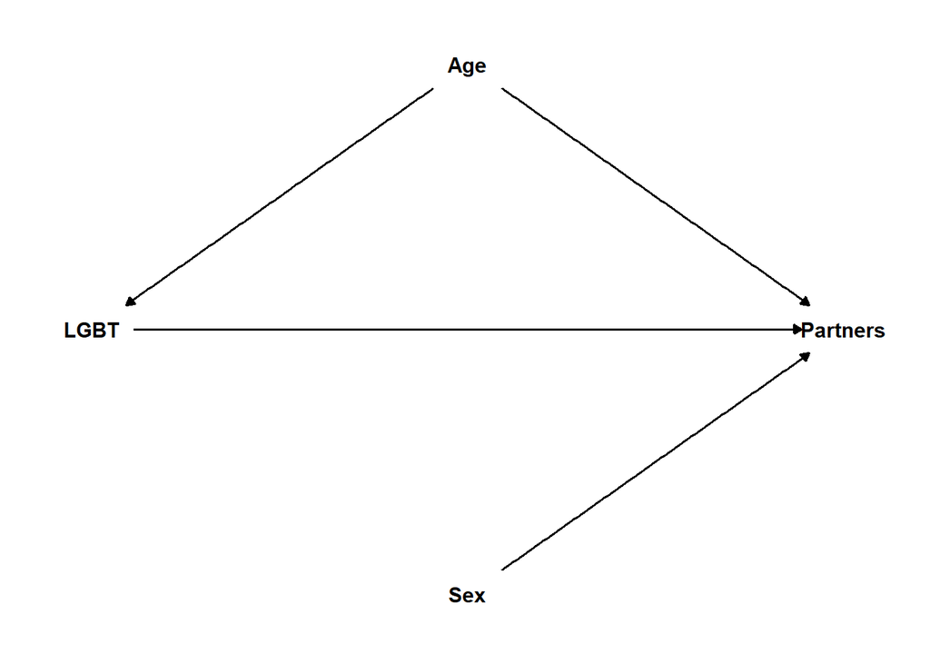

```r
dag_coords <-
  tibble(name = c("LGBT", "Partners", "Sex", "Age"),
         x = c(1, 3, 2, 2),
         y = c(2, 2, 1, 3))

dag <-
  dagify(Partners ~ LGBT + Sex + Age,
         LGBT ~ Age,
         coords = dag_coords)

dag %>%
  ggplot(aes(x = x, y = y, xend = xend, yend = yend)) +
  geom_dag_text(color = "black") +
  geom_dag_edges() +
  theme_dag()
```

I assume that age has an effect on reported queerness (e.g., the later in life, the more likely someone in the LGBTQ community has already had their coming out).

One could also assume that sex affects people’s sexuality. However, in this case, I’m,only interest in whether people are straight or not. Other sexualities (homo- and bisexual in the GSS) are grouped together.

Looking at some statistics on the sexuality of cis-gendered people, it seems that men and women are more or less equally as likely to say they’re not straight. Among them, men are more likely to say they’re gay (rather than bi) and women to say they’re bi (rather than lesbian).

But, since we group these orientations together as “non-straight”, we can neglect these gender differences.

## Getting the data

Loading and preparing data: The variables that interest us are sex, # of partners, sexuality, age, and marital status.

```r
d <- gss_get_yr(2018)  %>%
  select(partnrs5, sexornt, sex, marital, age) %>%
  drop_na() %>%
  haven::zap_labels()
```

```
## Fetching: https://gss.norc.org/documents/stata/2018_stata.zip
```

```r
table(d$partnrs5)
```

```
##
##   0   1   2   3   4   5   6   7   8   9
## 210 727 144  89  57  64  35   6   1  28
```

```r
table(d$sexornt)
```

```
##
##    1    2    3
##   31   51 1279
```

Some data wrangling: We get rid of married people and those who reported “more than 1 but not sure how many” as their # of partners (value 9). We group homo- and bisexuals together; it would be great to look at differences between them, but as we see above, there aren’t many queer respondents to begin with.

As we saw above, only few people reported to have had more than 10 partners in the last 5 years (values 6, 7, 8), so we also group all of them together. This values for this variable now mean 0, 1, 2, 3, 4, 5-10, or more than 10 partners.

I use the common age groups 18-24, 25-34, and so on up to 65+.

```r
dd <- d %>%
  filter(marital != 1) %>%
  filter(partnrs5 != 9) %>%
  mutate(lgbt = if_else(sexornt == 3, 0, 1),
         female = if_else(sex == 2, 1, 0),
         partners = case_when(
           partnrs5 == 0 ~ 0,
           partnrs5 == 1 ~ 1,
           partnrs5 == 2 ~ 2,
           partnrs5 == 3 ~ 3,
           partnrs5 == 4 ~ 4,
           partnrs5 == 5 ~ 5,
           partnrs5 >= 6 ~ 6,
         ),
         age = case_when(
           age >= 18 & age < 25 ~ 1,
           age >= 25 & age < 35 ~ 2,
           age >= 35 & age < 45 ~ 3,
           age >= 45 & age < 55 ~ 4,
           age >= 55 & age < 65 ~ 5,
           age >= 65 ~ 6,
         )) %>%
  select(lgbt, female, partners, age)
```

Now, we create our model. As priors, I went with people having an average of 2 sexual partners in the last 5 years, with values from 0 to 4 being common (std. dev. = 1).

I really don’t know a lot about how many partners people of different ages and genders might have, so I choose rather flexible priors for these parameters.

```r
flist <- alist(
  partners ~ dnorm(mu, sigma),
  mu <- a + bq*lgbt + bf*female + b_age[age],
  a ~ dnorm(2, 1),
  bf ~ dnorm(0, .5),
  bq ~ dnorm(0, .5),
  b_age[age] ~ dnorm(0, .5),
  sigma ~ dexp(1)
)
```

Let’s see what kind of distribution these prior would create:

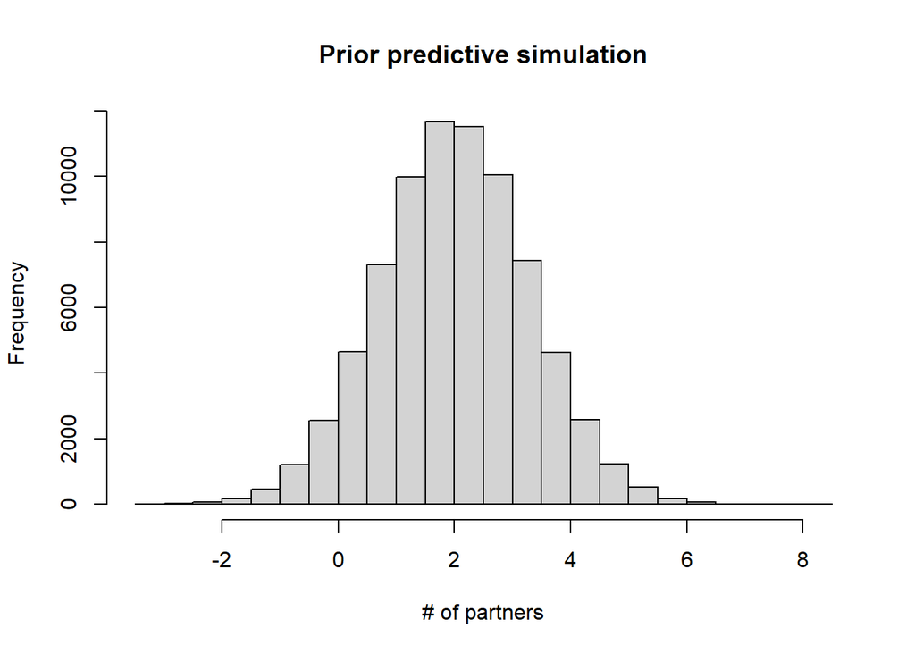

```r
ppsims <- dd %>%
  select(female) %>%
  uncount(100) %>%
  rowwise() %>%
  mutate(simcount =
           rnorm(1, 2, 1) +
           rnorm(1, 0, .5) * female +
           rnorm(1, 0, .5) +
           rnorm(1, 0, .5)
  )

hist(ppsims$simcount,
     main = "Prior predictive simulation",
     xlab = "# of partners")
```

This doesn’t look compeletly ridiculous.

Now, let’s estimate the model:

```r
m1 <- quap(
  flist,
  data = dd
)

precis(m1, depth = 2)
```

```
##                 mean         sd        5.5%       94.5%
## a         2.25834008 0.21592161  1.91325566  2.60342451
## bf       -0.76094525 0.11072657 -0.93790768 -0.58398281
## bq        0.70779413 0.18894403  0.40582507  1.00976320
## b_age[1]  0.43847711 0.23554329  0.06203344  0.81492079
## b_age[2]  0.72093227 0.22766645  0.35707731  1.08478723
## b_age[3]  0.54396205 0.23643388  0.16609505  0.92182904
## b_age[4] -0.02825691 0.24193001 -0.41490778  0.35839397
## b_age[5] -0.42210168 0.23415900 -0.79633299 -0.04787038
## b_age[6] -1.18787053 0.22976448 -1.55507855 -0.82066251
## sigma     1.52883861 0.03912766  1.46630504  1.59137217
```

Here, we can already see that most of our variables - sexuality, gender, and different age groups - have pretty significant effects on the number of partners.

Let’s draw samples from the posterior and plot the parameter values:

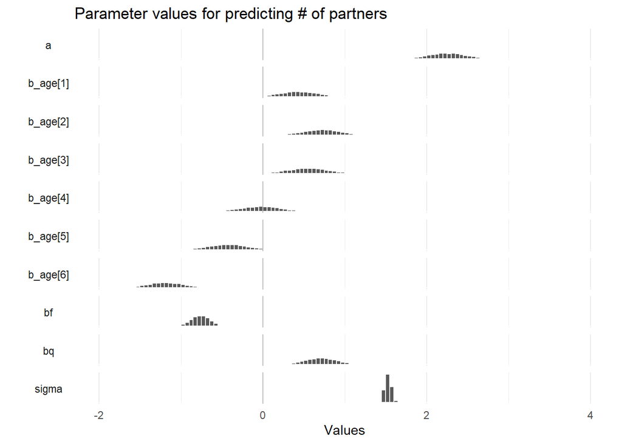

```r
post <- tidy_draws(m1, n = 1e4) %>%
  select(a:sigma)

longpost <- post %>%
  pivot_longer(everything(),
             names_to = "term",
             values_to = "values")

ggplot(longpost,
       aes(x = values)) +
  geom_histogram(color = "white",
                 binwidth = .05,
                 boundary = 0) +
  facet_grid(rows = vars(term),
             switch = "y") +
  geom_vline(xintercept = 0,
             color = "gray") +
  scale_y_continuous(breaks = NULL) +
  xlim(-2, 4) +
  labs(title = "Parameter values for predicting # of partners",
       y = "",
       x = "Values") +
  theme_minimal() +
  theme(strip.text.y.left = element_text(angle = 0))
```

To begin with, our intercept (average straight male) has had about two partners in the last 5 years.

As popular statistics would have us expect, being female lowers that value significantly (almost one partner less on average).

We also see that being under 45 is correlated with a high number of partners. The opposite is true for people over 55 and even more so for seniors (65+).

But what about the predictor we were interested about? Being not straight is in fact correlated with having had more sexual partners, even when holding age and gender constant. The effect is about as strong as that of gender: The average homo- or bisexual person has had almost one more sexual partner than their straight counterpart.

Of course, in this simple model we don’t take interactions into account.

For example, there’s probably be an interaction between the variables gender and sexuality. The effect that your gender has on your number of sexual partners might differ dependent on whether you’re straight or not.

In a similar way, I could imagine that age moderates the effect that sexuality has on one’s number of partners.

When we take the effects of all parameters independently, it looks like gay or bi men in the 25-35 age group had the most partners in the last years. As a queer man that turns 26 this weekend, I’m excited for the times ahead.